# index

## Introduction & Summary information

### Dataset introduction

I have used two dataset, Incarceration_trends and state code mapping dataset. The Incarceration_trends dataset includes the incarceration data and provides county-level data on prison and jail incarceration for the entire United States. The data also contains prison data grouped by different races. State code dataset includes the mapping of state region and state code (e.g. California -> CA).

### Problems

In this report, I would like to solve several problems, including:

1. As time goes by, is there a decrements of prison ratio?
2. Is there noteworthy prison ratio difference between different races in different level of urbanity?
3. As time goes by, is there noteworthy prison ratio difference between different races?

### Variables

I have used several variables from the dataset and generate several variables from them.

1. Year, range: from 1970 to 2018
2. State, the State code of the data. (e.g. CA)
3. Urbanicity, the urbanicity of the data, have 4 unique values: “rural”, “small/mid”, “suburban”, “urban”.
4. total_pop_15to64, the population count of ages 15 to 64, range: from 0 to 6958134
5. {races}_pop_15to64, the population of people between 15 and 64 with 5 different races: white, native, black, latinx, aapi.
6. total_jail_pop, total jail population count, range: from 0 to 23467
7. {races}_jail_pop, jail population with 5 difference races: white, native, black, latinx, aapi.
8. total_prison_ratio = total_jail_pop / total_pop_15to64
9. {races}_prison_ratio = {races}_jail_pop / {races}_pop_15to64

### Data preprocessing and cleaning

Because the calculation of prison ration relies on the population data of different races, which are N/A for the data before 1990, so I remove the data before 1990. And replace the rest N/A values with 0.

## Time trend Chart

For problem 1, I have plot the time trend of prison ratio of the top 10 population states in 2018. The plot shows:

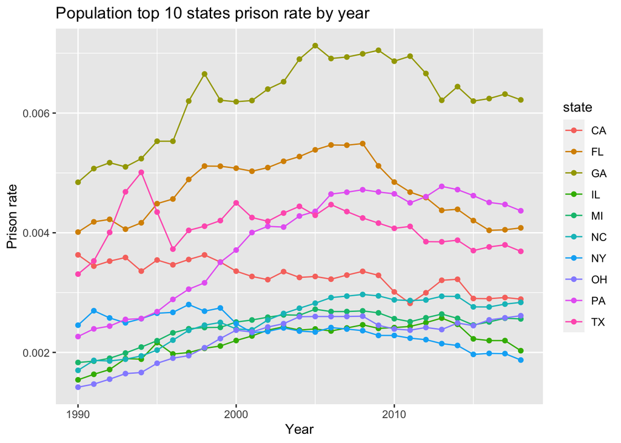

For problem 3, I have plot the time trend of prison ratio by different races for the state with highest prison ratio. From the plot we can find out that the black has higher prison ratio than other races, and the prison ratio has a decrements between 2009 and 2018. So I think the inequality do exists but the problem has been mitigated since recent years.

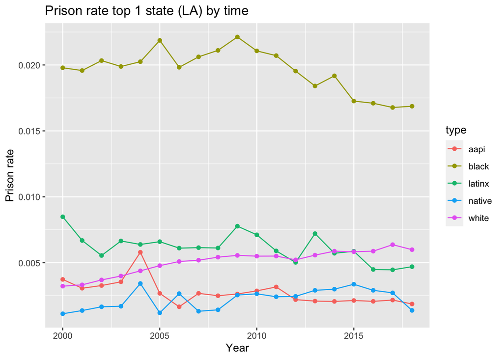

## Variable Comparison Chart

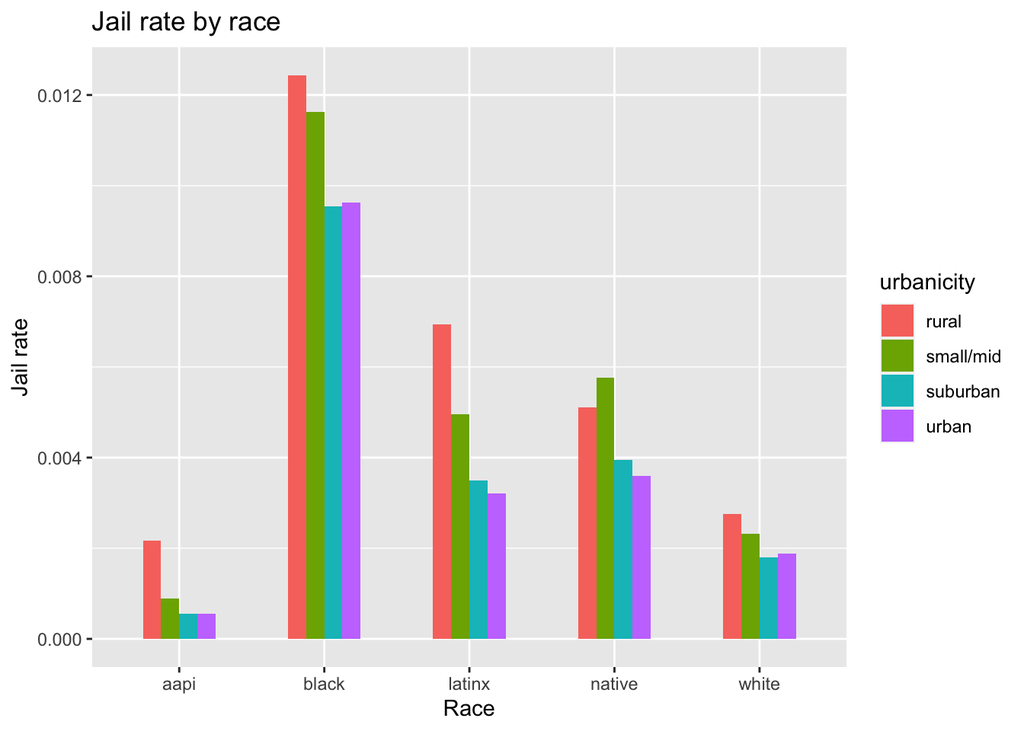

## Map

I have plot the map of US with the average prison ratio from 2000 to 2018, because I think prison ratio can reflect the public security situation of states and people can check and compare that in a single map.

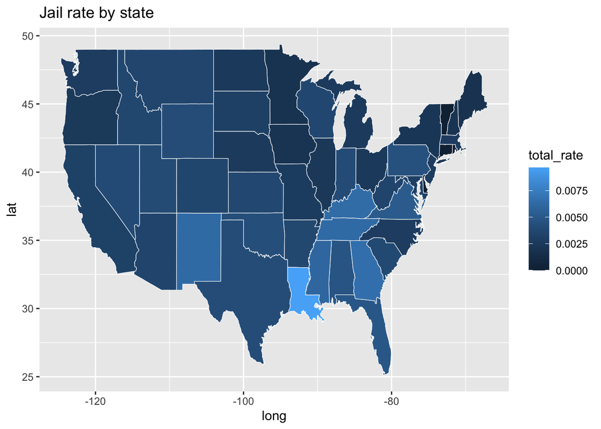